# CIFAR-10 Classification project CNN

```python
# fix for memory issues
import tensorflow as tf
gpus = tf.config.list_physical_devices('GPU')
if gpus:
    for gpu in gpus:
        tf.config.experimental.set_memory_growth(gpu, True)
```

```python
import keras
from tensorflow.keras.models import Sequential
from tensorflow.keras.layers import Input, Dense, Flatten, Dropout, BatchNormalization, Conv2D, MaxPooling2D
from tensorflow.keras import layers
from tensorflow.keras.utils import to_categorical
import matplotlib.pyplot as plt
```

### Data preparation

Load data and scale the values to 0.0-1.0 for better performance, no need to reshape for CNN

```python
# Load data
(x_train, y_train), (x_test, y_test) = keras.datasets.cifar10.load_data()
# Reshape and scale to 0.0-1.0
x_train = x_train.astype("float32")/255
x_test = x_test.astype("float32") /255
```

```python
print(x_train.shape, y_train.shape)
print(x_test.shape, y_test.shape)
```

```
(50000, 32, 32, 3) (50000, 1)
(10000, 32, 32, 3) (10000, 1)
```

### Model

```python
# Data augmentation module
data_augmentation = Sequential([
    layers.RandomFlip("horizontal"),
    layers.RandomRotation(0.1),
    layers.RandomZoom(0.1),
])
```

```python
# Build layers
model = Sequential([
    Input(shape=(32, 32, 3)),
    data_augmentation,
    Conv2D(32, (3, 3), padding="same", activation='relu'),
    BatchNormalization(),
    Conv2D(32, (3, 3), padding="same", activation='relu'),
    BatchNormalization(),
    MaxPooling2D((2, 2)),

    Conv2D(64, (3, 3), padding="same", activation='relu'),
    BatchNormalization(),
    Conv2D(64, (3, 3), padding="same", activation='relu'),
    BatchNormalization(),
    MaxPooling2D((2, 2)),

    Conv2D(128, (3, 3), padding="same", activation='relu'),
    BatchNormalization(),
    Conv2D(128, (3, 3), padding="same", activation='relu'),
    BatchNormalization(),
    MaxPooling2D((2, 2)),

    Flatten(),
    Dense(64, activation='relu'),
    Dropout(0.3),
    Dense(10, activation='softmax')
])
```

```python
# Model options
model.compile(optimizer='adam',
              loss=keras.losses.SparseCategoricalCrossentropy(),
              metrics=['accuracy'],
)
```

```python
# Training options
history = model.fit(x_train, y_train, epochs=50, batch_size=32, validation_split=0.2)
```

```
1250/1250 ━━━━━━━━━━━━━━━━━━━━ 52s 38ms/step - accuracy: 0.3302 - loss: 1.8194 - val_accuracy: 0.4314 - val_loss: 1.6238
1250/1250 ━━━━━━━━━━━━━━━━━━━━ 46s 37ms/step - accuracy: 0.4528 - loss: 1.4947 - val_accuracy: 0.4907 - val_loss: 1.4152
1250/1250 ━━━━━━━━━━━━━━━━━━━━ 46s 37ms/step - accuracy: 0.5233 - loss: 1.3289 - val_accuracy: 0.5970 - val_loss: 1.1790
1250/1250 ━━━━━━━━━━━━━━━━━━━━ 46s 37ms/step - accuracy: 0.5824 - loss: 1.1914 - val_accuracy: 0.5960 - val_loss: 1.2689
1250/1250 ━━━━━━━━━━━━━━━━━━━━ 45s 36ms/step - accuracy: 0.6191 - loss: 1.0990 - val_accuracy: 0.6674 - val_loss: 0.9876
1250/1250 ━━━━━━━━━━━━━━━━━━━━ 46s 37ms/step - accuracy: 0.6493 - loss: 1.0247 - val_accuracy: 0.6966 - val_loss: 0.8973
1250/1250 ━━━━━━━━━━━━━━━━━━━━ 45s 36ms/step - accuracy: 0.6740 - loss: 0.9642 - val_accuracy: 0.7197 - val_loss: 0.8470
1250/1250 ━━━━━━━━━━━━━━━━━━━━ 43s 35ms/step - accuracy: 0.6951 - loss: 0.8992 - val_accuracy: 0.7307 - val_loss: 0.8418
1250/1250 ━━━━━━━━━━━━━━━━━━━━ 45s 36ms/step - accuracy: 0.7095 - loss: 0.8628 - val_accuracy: 0.7179 - val_loss: 0.8924
1250/1250 ━━━━━━━━━━━━━━━━━━━━ 44s 35ms/step - accuracy: 0.7240 - loss: 0.8208 - val_accuracy: 0.7384 - val_loss: 0.7754
1250/1250 ━━━━━━━━━━━━━━━━━━━━ 43s 34ms/step - accuracy: 0.7308 - loss: 0.7989 - val_accuracy: 0.7426 - val_loss: 0.7858
1250/1250 ━━━━━━━━━━━━━━━━━━━━ 43s 34ms/step - accuracy: 0.7458 - loss: 0.7584 - val_accuracy: 0.7796 - val_loss: 0.6828
1250/1250 ━━━━━━━━━━━━━━━━━━━━ 42s 34ms/step - accuracy: 0.7548 - loss: 0.7306 - val_accuracy: 0.7729 - val_loss: 0.6840
1250/1250 ━━━━━━━━━━━━━━━━━━━━ 44s 35ms/step - accuracy: 0.7581 - loss: 0.7222 - val_accuracy: 0.7676 - val_loss: 0.6929
1250/1250 ━━━━━━━━━━━━━━━━━━━━ 43s 34ms/step - accuracy: 0.7667 - loss: 0.6924 - val_accuracy: 0.7718 - val_loss: 0.7100
1250/1250 ━━━━━━━━━━━━━━━━━━━━ 41s 33ms/step - accuracy: 0.7767 - loss: 0.6658 - val_accuracy: 0.7871 - val_loss: 0.6548
1250/1250 ━━━━━━━━━━━━━━━━━━━━ 43s 35ms/step - accuracy: 0.7828 - loss: 0.6494 - val_accuracy: 0.7981 - val_loss: 0.5910
1250/1250 ━━━━━━━━━━━━━━━━━━━━ 42s 34ms/step - accuracy: 0.7865 - loss: 0.6398 - val_accuracy: 0.8152 - val_loss: 0.5644
1250/1250 ━━━━━━━━━━━━━━━━━━━━ 44s 35ms/step - accuracy: 0.7929 - loss: 0.6154 - val_accuracy: 0.7722 - val_loss: 0.6920
1250/1250 ━━━━━━━━━━━━━━━━━━━━ 44s 35ms/step - accuracy: 0.7935 - loss: 0.6067 - val_accuracy: 0.7980 - val_loss: 0.6053
1250/1250 ━━━━━━━━━━━━━━━━━━━━ 43s 34ms/step - accuracy: 0.8017 - loss: 0.5897 - val_accuracy: 0.7915 - val_loss: 0.6333
1250/1250 ━━━━━━━━━━━━━━━━━━━━ 44s 35ms/step - accuracy: 0.8073 - loss: 0.5710 - val_accuracy: 0.7882 - val_loss: 0.6517
1250/1250 ━━━━━━━━━━━━━━━━━━━━ 42s 33ms/step - accuracy: 0.8080 - loss: 0.5675 - val_accuracy: 0.8214 - val_loss: 0.5449
1250/1250 ━━━━━━━━━━━━━━━━━━━━ 45s 36ms/step - accuracy: 0.8098 - loss: 0.5585 - val_accuracy: 0.8204 - val_loss: 0.5355
1250/1250 ━━━━━━━━━━━━━━━━━━━━ 47s 37ms/step - accuracy: 0.8155 - loss: 0.5475 - val_accuracy: 0.8098 - val_loss: 0.5941
1250/1250 ━━━━━━━━━━━━━━━━━━━━ 43s 34ms/step - accuracy: 0.8174 - loss: 0.5389 - val_accuracy: 0.8136 - val_loss: 0.5707
1250/1250 ━━━━━━━━━━━━━━━━━━━━ 45s 36ms/step - accuracy: 0.8210 - loss: 0.5308 - val_accuracy: 0.8169 - val_loss: 0.5614
1250/1250 ━━━━━━━━━━━━━━━━━━━━ 42s 33ms/step - accuracy: 0.8211 - loss: 0.5192 - val_accuracy: 0.8296 - val_loss: 0.5233
1250/1250 ━━━━━━━━━━━━━━━━━━━━ 45s 36ms/step - accuracy: 0.8275 - loss: 0.5096 - val_accuracy: 0.8049 - val_loss: 0.6429
1250/1250 ━━━━━━━━━━━━━━━━━━━━ 44s 35ms/step - accuracy: 0.8260 - loss: 0.5129 - val_accuracy: 0.8256 - val_loss: 0.5243
1250/1250 ━━━━━━━━━━━━━━━━━━━━ 44s 35ms/step - accuracy: 0.8334 - loss: 0.4929 - val_accuracy: 0.8235 - val_loss: 0.5518
1250/1250 ━━━━━━━━━━━━━━━━━━━━ 44s 35ms/step - accuracy: 0.8362 - loss: 0.4814 - val_accuracy: 0.8283 - val_loss: 0.5392
1250/1250 ━━━━━━━━━━━━━━━━━━━━ 42s 33ms/step - accuracy: 0.8375 - loss: 0.4768 - val_accuracy: 0.8196 - val_loss: 0.5567
1250/1250 ━━━━━━━━━━━━━━━━━━━━ 44s 35ms/step - accuracy: 0.8407 - loss: 0.4729 - val_accuracy: 0.8272 - val_loss: 0.5361
1250/1250 ━━━━━━━━━━━━━━━━━━━━ 42s 34ms/step - accuracy: 0.8386 - loss: 0.4718 - val_accuracy: 0.8196 - val_loss: 0.5686
1250/1250 ━━━━━━━━━━━━━━━━━━━━ 45s 36ms/step - accuracy: 0.8426 - loss: 0.4583 - val_accuracy: 0.8258 - val_loss: 0.5607
1250/1250 ━━━━━━━━━━━━━━━━━━━━ 44s 36ms/step - accuracy: 0.8475 - loss: 0.4541 - val_accuracy: 0.8330 - val_loss: 0.5348
1250/1250 ━━━━━━━━━━━━━━━━━━━━ 42s 34ms/step - accuracy: 0.8455 - loss: 0.4554 - val_accuracy: 0.8391 - val_loss: 0.5174
1250/1250 ━━━━━━━━━━━━━━━━━━━━ 44s 35ms/step - accuracy: 0.8454 - loss: 0.4502 - val_accuracy: 0.8429 - val_loss: 0.4919
1250/1250 ━━━━━━━━━━━━━━━━━━━━ 43s 34ms/step - accuracy: 0.8497 - loss: 0.4448 - val_accuracy: 0.8490 - val_loss: 0.4811
1250/1250 ━━━━━━━━━━━━━━━━━━━━ 44s 35ms/step - accuracy: 0.8539 - loss: 0.4321 - val_accuracy: 0.8342 - val_loss: 0.5174
1250/1250 ━━━━━━━━━━━━━━━━━━━━ 44s 35ms/step - accuracy: 0.8548 - loss: 0.4316 - val_accuracy: 0.8420 - val_loss: 0.4870
1250/1250 ━━━━━━━━━━━━━━━━━━━━ 42s 34ms/step - accuracy: 0.8529 - loss: 0.4259 - val_accuracy: 0.8285 - val_loss: 0.5379
1250/1250 ━━━━━━━━━━━━━━━━━━━━ 44s 35ms/step - accuracy: 0.8563 - loss: 0.4203 - val_accuracy: 0.8274 - val_loss: 0.5370
1250/1250 ━━━━━━━━━━━━━━━━━━━━ 42s 34ms/step - accuracy: 0.8584 - loss: 0.4180 - val_accuracy: 0.8342 - val_loss: 0.5359
1250/1250 ━━━━━━━━━━━━━━━━━━━━ 43s 35ms/step - accuracy: 0.8579 - loss: 0.4154 - val_accuracy: 0.8302 - val_loss: 0.5325
1250/1250 ━━━━━━━━━━━━━━━━━━━━ 43s 34ms/step - accuracy: 0.8600 - loss: 0.4127 - val_accuracy: 0.8429 - val_loss: 0.5262
1250/1250 ━━━━━━━━━━━━━━━━━━━━ 41s 33ms/step - accuracy: 0.8600 - loss: 0.4053 - val_accuracy: 0.8364 - val_loss: 0.4993
1250/1250 ━━━━━━━━━━━━━━━━━━━━ 43s 35ms/step - accuracy: 0.8633 - loss: 0.4013 - val_accuracy: 0.8379 - val_loss: 0.5257
1250/1250 ━━━━━━━━━━━━━━━━━━━━ 42s 33ms/step - accuracy: 0.8621 - loss: 0.4012 - val_accuracy: 0.8484 - val_loss: 0.4746
```

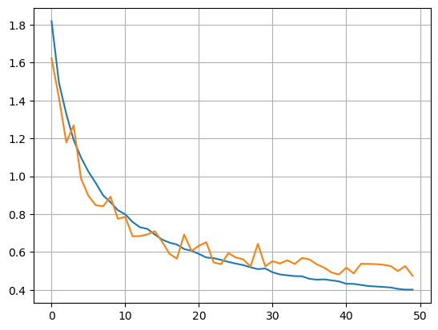

```python
# Plot validation loss compared to loss
plt.plot(history.history["loss"])
plt.plot(history.history["val_loss"])
plt.grid()
plt.show()
```

```python
test_scores = model.evaluate(x_test, y_test, verbose=2)
print("Test loss:", test_scores[0])
print("Test accuracy:", test_scores[1])
```

```
313/313 - 2s - 8ms/step - accuracy: 0.8402 - loss: 0.4934
Test loss: 0.4934389591217041
Test accuracy: 0.8402000069618225
```

```python
model.summary()
```

```
Model: "sequential_4"
```

```
┏━━━━━━━━━━━━━━━━━━━━━━━━━━━━━━━━━┳━━━━━━━━━━━━━━━━━━━━━━━━┳━━━━━━━━━━━━━━━┓
┃ Layer (type)                    ┃ Output Shape           ┃       Param # ┃
┡━━━━━━━━━━━━━━━━━━━━━━━━━━━━━━━━━╇━━━━━━━━━━━━━━━━━━━━━━━━╇━━━━━━━━━━━━━━━┩
│ sequential_3 (Sequential)       │ (None, 32, 32, 3)      │             0 │
├─────────────────────────────────┼────────────────────────┼───────────────┤
│ conv2d_6 (Conv2D)               │ (None, 32, 32, 32)     │           896 │
├─────────────────────────────────┼────────────────────────┼───────────────┤
│ batch_normalization_6           │ (None, 32, 32, 32)     │           128 │
│ (BatchNormalization)            │                        │               │
├─────────────────────────────────┼────────────────────────┼───────────────┤
│ conv2d_7 (Conv2D)               │ (None, 32, 32, 32)     │         9,248 │
├─────────────────────────────────┼────────────────────────┼───────────────┤
│ batch_normalization_7           │ (None, 32, 32, 32)     │           128 │
│ (BatchNormalization)            │                        │               │
├─────────────────────────────────┼────────────────────────┼───────────────┤
│ max_pooling2d_3 (MaxPooling2D)  │ (None, 16, 16, 32)     │             0 │
├─────────────────────────────────┼────────────────────────┼───────────────┤
│ conv2d_8 (Conv2D)               │ (None, 16, 16, 64)     │        18,496 │
├─────────────────────────────────┼────────────────────────┼───────────────┤
│ batch_normalization_8           │ (None, 16, 16, 64)     │           256 │
│ (BatchNormalization)            │                        │               │
├─────────────────────────────────┼────────────────────────┼───────────────┤
│ conv2d_9 (Conv2D)               │ (None, 16, 16, 64)     │        36,928 │
├─────────────────────────────────┼────────────────────────┼───────────────┤
│ batch_normalization_9           │ (None, 16, 16, 64)     │           256 │
│ (BatchNormalization)            │                        │               │
├─────────────────────────────────┼────────────────────────┼───────────────┤
│ max_pooling2d_4 (MaxPooling2D)  │ (None, 8, 8, 64)       │             0 │
├─────────────────────────────────┼────────────────────────┼───────────────┤
│ conv2d_10 (Conv2D)              │ (None, 8, 8, 128)      │        73,856 │
├─────────────────────────────────┼────────────────────────┼───────────────┤
│ batch_normalization_10          │ (None, 8, 8, 128)      │           512 │
│ (BatchNormalization)            │                        │               │
├─────────────────────────────────┼────────────────────────┼───────────────┤
│ conv2d_11 (Conv2D)              │ (None, 8, 8, 128)      │       147,584 │
├─────────────────────────────────┼────────────────────────┼───────────────┤
│ batch_normalization_11          │ (None, 8, 8, 128)      │           512 │
│ (BatchNormalization)            │                        │               │
├─────────────────────────────────┼────────────────────────┼───────────────┤
│ max_pooling2d_5 (MaxPooling2D)  │ (None, 4, 4, 128)      │             0 │
├─────────────────────────────────┼────────────────────────┼───────────────┤
│ flatten_1 (Flatten)             │ (None, 2048)           │             0 │
├─────────────────────────────────┼────────────────────────┼───────────────┤
│ dense_2 (Dense)                 │ (None, 64)             │       131,136 │
├─────────────────────────────────┼────────────────────────┼───────────────┤
│ dropout_1 (Dropout)             │ (None, 64)             │             0 │
├─────────────────────────────────┼────────────────────────┼───────────────┤
│ dense_3 (Dense)                 │ (None, 10)             │           650 │
└─────────────────────────────────┴────────────────────────┴───────────────┘
```

```
 Total params: 1,259,968 (4.81 MB)
```

```
 Trainable params: 419,690 (1.60 MB)
```

```
 Non-trainable params: 896 (3.50 KB)
```

```
 Optimizer params: 839,382 (3.20 MB)
```

### Model tuning methodology

Did a lot of different variations of the model. Tried increasing layers/cells to increase accuracy, but overfitting became a problem with when trying to increase epochs. Started with a few CNN-cells with max pooling between. One extra dense layer at the end helped with accuracy. Tried adding dropouts, but multiple dropouts seemed to make validation loss very erratic. Batch normalization helped with accuracy and overfitting enough to be able to add more epochs to get much better accuracy. To add more convolution layers had to add padding to the layers so the pictures don't get too small and not max pool between every layer(basicly 3 max pool layers is the maximum for 32x32 pictures since that already makes them 4x4). Added data augmentation with flip, rotation and zoom which increased accuracy even more (data augmentation also increased training time drasticly).

In short the goal was to add enough overfitting reducing qualities to be able to train longer with more layers to get the best accuracy.

### Analysis

From the example predictions results below we see that for a lot of the pictures the model is very confident(>90%) on it's prediction. We see this in pictures 7 and 10 where it's very confidently predicting wrong. In the pictures with more mixed predictions there's a pattern of very unusual pictures of target category e.g. picture 18 is just a horse's head and picture 12 is a side profile of a cat which would be hard to differentiate from many other animals.

### Comparison between CNN and FCN

The CNN model achieved much better accuracy on the test set (84% vs 51%). Learning/loss curves for the CNN-model is much steeper because it "gained" more accuracy. The CNN-models validation loss curve was smoother than the FCN-models. The training accuracy is also much closer to the test accuracy in the CNN-model indicating less overfitting and more reliable results. The FNC-model had 3.8 million trainable parameters while the CNN-model had 400 000 parameters. The discrepancy would be even larger with bigger pictures since in a FCN each pixel has it's own trainable parameters whereas in CNN the filter's have paramateres not individual pictures. Even so the CNN-model was much slower to train ~35 minutes comapred to ~4 minutes of FCN largely because it went through more epochs, but also because it had more layers and the data augmentation slowed training by ~2x-3x.

CNN is better than FNC for picture recognition because a pixel doesn't lose the context of any of the other pixels next to it and the shapes it finds are not tied to a specific location in the picture. It specificly relies on nearby/adjacent pixels to find features in a picture by finding patterns(e.g. horizontal or diagonal lines etc.). Where FNC basicly just tries to find the relationships between pixels in a 1d vector, CNN can find patterns between nearby pixels.

```
20/20 ━━━━━━━━━━━━━━━━━━━━ 0s 8ms/step
```

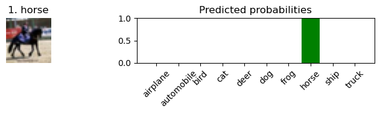

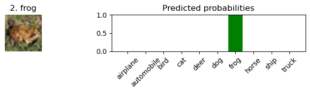

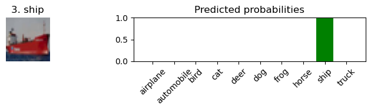

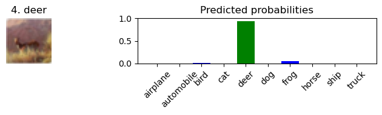

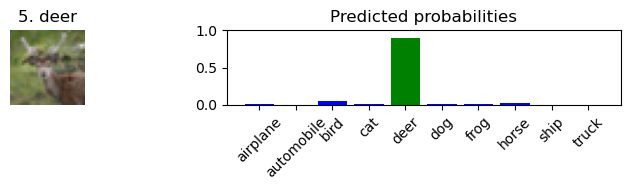

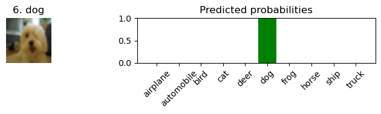

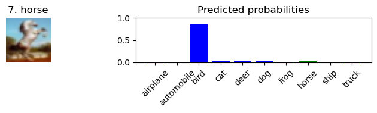

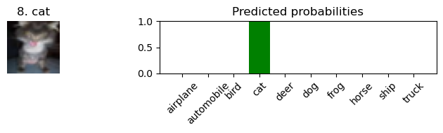

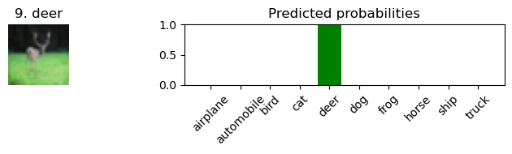

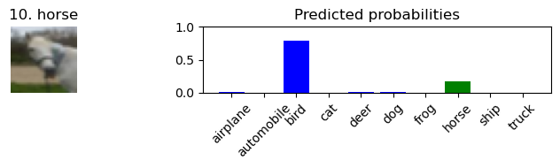

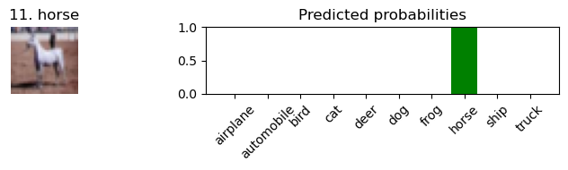

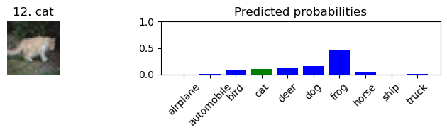

[8 more figures not shown]

```python
import numpy as np
import matplotlib.pyplot as plt

x = x_test
start = 5000
# only predict needed ones since VRAM ran out :(
y_pred = model.predict(x[start:start+20], batch_size=1)
labels = ["airplane","automobile","bird","cat","deer","dog","frog","horse","ship","truck"]

for k in range(20):
    plt.figure(figsize=(8, 2))

    # Show image
    plt.subplot(1, 2, 1)
    plt.imshow(x[start+k].reshape((32, 32, 3)))
    plt.axis("off")
    true_label_idx = int(y_test[start+k]) if y_test.ndim == 1 else int(y_test[start+k, 0])
    plt.title(f"{k+1}. {labels[true_label_idx]}")

    # Show bar graph
    plt.subplot(1, 2, 2)
    probs = y_pred[k].flatten()

    # Color the correct label green
    colors = ["green" if i == true_label_idx else "blue" for i in range(10)]
    plt.bar(range(10), probs, color=colors)
    plt.xticks(range(10), labels, rotation=45)
    plt.ylim([0, 1])
    plt.title("Predicted probabilities")

    plt.tight_layout()
    plt.show()
```

```python
# Save model
model.save('./CIFAR_10_CNN.keras')
```